# 01_CleanData

Sophie Buysse

2026-05-19

# description

This code reads in the raw data and writes out cleaned data files. A Two Treatment version was saved on 7/21/2025 so all histograms were done with only the data being used for analysis in this manuscript. (the third treatment, where plants were in the Current treatment before vernalization but the Future treatment after was completed and is present in the raw data but was not included in analyses.)

# Set basic info for all code

This chunk sets things that will be constant for the whole document.

Load packages:

```r
#setup code here

# read in packages
library(dplyr)
library(ggplot2)
library(tidyr)
library(rcompanion)
```

Make functions:

```r
# prep for doing statistical analyses
options(contrasts = c("contr.sum", "contr.poly"))

# for exploring transformations
explore_trans <- function(trait){
  plotNormalHistogram(trait)
  plotNormalHistogram(log10(trait))
  plotNormalHistogram(exp(trait))
  plotNormalHistogram(sqrt(trait))
  # want the one with the largest value
  print(shapiro.test(trait))
  print(shapiro.test(log10(trait)))
  print(shapiro.test(exp(trait)))
  print(shapiro.test(sqrt(trait)))
}

# standard error of the mean
std_mean <- function(x){
  sd(x, na.rm = TRUE)/sqrt(length(x))
}

# Confidence interval multiplier for standard error
    # Calculate t-statistic for confidence interval:
    # e.g., if conf.interval is .95, use .975 (above/below), and use df=N-1

conf_int <- function(x, conf.interval = 0.95){
  ciMult <- qt((1+conf.interval)/2, length(x)-1)
  ci <- std_mean(x) * ciMult
  return(ci)
}
```

# 2021

## Load in Data

Raw Data files not on github.

```r
SingleLeaf <- read.csv("data/2021_raw/SingleLeaf_green.csv")
Harv_blue <- read.csv("data/2021_raw/Harvest_blue.csv")
Harv_pink <- read.csv("data/2021_raw/Harvest_pink_ImageJ.csv")
LeafNum <- read.csv("data/2021_raw/Leaf Number_yellow.csv")
Phenology <-read.csv("data/2021_raw/Phenology.csv")
PlantingDay <- read.csv("data/2021_raw/PlantingDay.csv")
```

## Clean up data

The goal of this code is to identify any entering errors and fix them, go through the notes and remove any traits that may not be accurate (i.e., if a plant was dropped or otherwise damaged before harvest), and create one data frame that includes all trait information for all individuals.

Note: There was a labelling error that is fixed later on. IT RIL Parent seeds ordered from the stock center were labelled as B1 instead of the correct B12. This is fixed below. Fixed labels were given unique IDs so they did not overlap with already existing labels and could be identified later.

```r
# there were steps to put things in notes columns and make sure NAs were missing values and zeros were zeros prior to this step that were done in excel.

Harv_blue <- Harv_blue[!(is.na(Harv_blue$Line)), c(1:14)]
colnames(Harv_blue) <- c("Population", "Line", "Replicate", "Treatment", "Pot.ID", "Harvest.Date", "RosetteLeafNum", "FreshRosetteG", "DryRosetteG", "FreshReproG", "DryReproG", "FreshRootG", "DryRootG", "Notes")

# calculate biomass allocation
# root to shoot ratio is the root mass divided by all above ground biomass (dry)
Harv_blue$Root_to_Shoot <- Harv_blue$DryRootG/(Harv_blue$DryRosetteG + Harv_blue$DryReproG)
# reproductive to rosette is the reproductive weight divided by the rosette weight. Decided to go this way so that a higher value indicates more investment in
# reproductive tissue relative to the rosette weight it has
Harv_blue$Repro_to_Ros <- Harv_blue$DryReproG / Harv_blue$DryRosetteG

# fix envelope labeling mistake and fill in with accurate values; while there was a mistake here, my lab notebook says " I put some of the R47-1-C reproductive in the R21-1-C reproductive envelope. I could kind of fix it, but R47-1 might be low and R21-1 might be high so I should discard both of these reproductive weights. Thus, commenting out these lines and leaving them as NA values.
#Harv_blue[Harv_blue$Pot.ID == "R21-1-C", "DryReproG"] <- 2.0414
#Harv_blue[Harv_blue$Pot.ID == "R47-1-C", "DryReproG"] <- 1.2501

#R35-2-C was dropped before flowering (on 10/14) so I am dropping the value on anything collected post the drop (i.e., the harvest datasheets, the other is done below).
Harv_blue <- Harv_blue[!(Harv_blue$Pot.ID == "R35-2-C"), ]

colnames(Harv_pink) <- c("Population", "Line", "Replicate", "Treatment", "Pot.ID", "IJ_FruitCount", "FruitCounter", "BranchStructure", "LatBranches", "PrimaryStalks", "Height_cm", "TotFruit", "FruitCollected", "FruitColLocation", "DoneFlwr", "NumFlwrLeft", "Notes", "FruitColWt_mg", "SeedColWt_mg", "ScanPosition", "ScanPhotoName", "IJ_SeedCount", "SeedCounter", "FruitCount_BL", "Notes2")

# remove extra rows in .csv + R35-2-C
Harv_pink <- Harv_pink[!(is.na(Harv_pink$Line)), ]
Harv_pink <- Harv_pink[!(Harv_pink$Pot.ID == "R35-2-C"), ]

LeafNum <- LeafNum[!(is.na(LeafNum$Weigh.Order)), c(1:18)]

Phenology <- Phenology[!(is.na(Phenology$Weigh.Order)), c(1:12)]
Phenology[Phenology$Pot.ID == "R35-2-C", "Flowering"] <- NA
# fix data entry error
Phenology[Phenology$Pot.ID == "R35-1-C", "Bolting"] <- "10/12/2021"

PlantingDay <- PlantingDay[c(1:150), c(1:18)]

rm_these <- c("B13-2-CF", "B3-2-CF", "R35-2-C") # remove doubles (B13-2-CF from 9/22, B3-2-CF from 9/22, R35-2-C b/c dropped before flowering so I am dropping the value on anything collected post the drop
SingleLeaf <- SingleLeaf[!(SingleLeaf$Pot.ID %in% rm_these), ]
# then rename the doubles so they will merge correctly
SingleLeaf[SingleLeaf$Pot.ID == "B13-2-CF2", "Pot.ID"] <- "B13-2-CF"
SingleLeaf[SingleLeaf$Pot.ID == "B3-2-CF2", "Pot.ID"] <- "B3-2-CF"
# and get rid of extra rows at the end
SingleLeaf <- SingleLeaf[!(is.na(SingleLeaf$Line)), ]

# Calculate drought traits
# SLA = leaf area / leaf dry mass
SingleLeaf$SLA <- SingleLeaf$LeafArea/SingleLeaf$DriedWt_g
# LDMC = dry mass / saturated mass
SingleLeaf$LDMC = SingleLeaf$DriedWt_g / SingleLeaf$SatWt_g
# RWC = (fresh mass - dry mass) / (saturated mass - dry mass)
### Note: this is the one that would be impacted by not always collecting the leaves at the same time of day
SingleLeaf$RWC = (SingleLeaf$FreshWt_g - SingleLeaf$DriedWt_g) / (SingleLeaf$SatWt_g - SingleLeaf$DriedWt_g)
```

At this point, sorted each dataframe by values to identify any high or low outliers. Did not find anything that was attributed to data entry errors. Also went through the notes columns to see if anything should be removed.

Fruit counts seem inconsistent. Near end of harvesting realized that clicker used to count fruits was skipping 10 or even 100 sometimes. Went back to images and recounted fruits in ImageJ, but some of these seem very different (196 initially and then 973 from ImageJ) so concerned about accuracy of that value as well. Had fruit number recounted from images a third time and used those values in the manuscript.

Leaf number is also variable with some counted at bolting and some at flowering so may need to toss that trait.

## Merge together

Now, merge data frames together

```r
AllData_2021 <- merge(PlantingDay, Phenology, by = c("Pot.ID", "Population", "Line", "Replicate", "Treatment"), all = TRUE)
AllData_2021 <- merge(AllData_2021, SingleLeaf, by = c("Pot.ID", "Population", "Line", "Replicate", "Treatment"), all = TRUE)
AllData_2021 <- merge(AllData_2021, LeafNum, by = c("Pot.ID", "Population", "Line", "Replicate", "Treatment"), all = TRUE)
AllData_2021 <- merge(AllData_2021, Harv_blue, by = c("Pot.ID", "Population", "Line", "Replicate", "Treatment"), all = TRUE)
AllData_2021 <- merge(AllData_2021, Harv_pink, by = c("Pot.ID", "Population", "Line", "Replicate", "Treatment"), all = TRUE)
# there's lots of notes columns at this point but that is okay.
# notes column names are repeated

# remove weigh.order columns b/c not relevant here
AllData_2021$Weigh.Order.x <- NULL
AllData_2021$Weigh.Order.y <- NULL

# fix Pot.ID labelling error
# Pop = BELM
# Line = 1 - change to 12
# Rep = 1:5 - change to 11:15
# need to change Pot.IDs
change.these <- c("B1-1-C", "B1-1-CF", "B1-1-F", "B1-2-C", "B1-2-CF", "B1-2-F", "B1-3-C", "B1-3-CF", "B1-3-F", "B1-4-C", "B1-4-CF", "B1-4-F", "B1-5-C", "B1-5-CF", "B1-5-F")
AllData_2021[AllData_2021$Pot.ID %in% change.these, "Line"] <- 12
AllData_2021[AllData_2021$Pot.ID %in% change.these & AllData_2021$Replicate == 1, "Replicate"] <- 11
AllData_2021[AllData_2021$Pot.ID %in% change.these & AllData_2021$Replicate == 2, "Replicate"] <- 12
AllData_2021[AllData_2021$Pot.ID %in% change.these & AllData_2021$Replicate == 3, "Replicate"] <- 13
AllData_2021[AllData_2021$Pot.ID %in% change.these & AllData_2021$Replicate == 4, "Replicate"] <- 14
AllData_2021[AllData_2021$Pot.ID %in% change.these & AllData_2021$Replicate == 5, "Replicate"] <- 15
AllData_2021[AllData_2021$Pot.ID %in% change.these, "Pot.ID"] <- c("B12-11-C", "B12-11-CF", "B12-11-F", "B12-12-C", "B12-12-CF", "B12-12-F", "B12-13-C", "B12-13-CF", "B12-13-F", "B12-14-C", "B12-14-CF", "B12-14-F", "B12-15-C", "B12-15-CF", "B12-15-F")

str(AllData_2021)
```

```
## 'data.frame':    150 obs. of  79 variables:
##  $ Pot.ID                          : chr  "B12-11-C" "B12-11-CF" "B12-11-F" "B12-12-C" ...
##  $ Population                      : chr  "BELM" "BELM" "BELM" "BELM" ...
##  $ Line                            : chr  "12" "12" "12" "12" ...
##  $ Replicate                       : chr  "11" "11" "11" "12" ...
##  $ Treatment                       : chr  "Current" "Current/Future" "Future" "Current" ...
##  $ pot.labelled.                   : chr  "yes" "yes" "yes" "yes" ...
##  $ Labelled.Pot.Weight..g.         : chr  "6.817" "6.443" "6.859" "6.64" ...
##  $ Pot...dry.Soil.Weight..g.       : chr  "56.8417" "56.493" "56.413" "56.914" ...
##  $ Soil.Added.Weight..g.           : chr  "50.0247" "50.05" "49.554" "50.274" ...
##  $ Soil.Mix.Batch.Number.x         : chr  "1" "1" "1" "4" ...
##  $ Pot...wet.soil.weight..g.       : chr  "180.05" "176.53" "185.43" "157.72" ...
##  $ Water.weight..g.                : chr  "123.21" "120.04" "129.02" "100.81" ...
##  $ H20.g....soil..g.               : chr  "2.46" "2.40" "2.60" "2.01" ...
##  $ First.Calc.of.FC.weight         : chr  "120.77" "120.83" "119.63" "121.37" ...
```

[output cut: 65 more lines]

```r
# and write this out
write.csv(AllData_2021,"data/AllData_2021.csv", row.names = FALSE)

#note NumRemoved_08262021 -> I can use this column to only include things that were still alive after 8/26. if y in this column, pot was dead/removed on this date. If "n", then plant alive and kept
```

Now clean up R environment

```r
rm("Harv_blue", "Harv_pink", "LeafNum", "Phenology", "PlantingDay", "SingleLeaf", "change.these", "rm_these")
```

Now clean up AllData dataframe

```r
# first make factors
AllData_2021$Population <- as.factor(AllData_2021$Population)
AllData_2021$Treatment <- as.factor(AllData_2021$Treatment)
AllData_2021$Soil.Mix.Batch.Number.x <- as.factor(AllData_2021$Soil.Mix.Batch.Number.x)
AllData_2021$BranchStructure <- as.factor(AllData_2021$BranchStructure)
AllData_2021$DoneFlwr <- as.factor(AllData_2021$DoneFlwr)
AllData_2021$FruitCounter <- as.factor(AllData_2021$FruitCounter)
AllData_2021$SeedCounter <- as.factor(AllData_2021$SeedCounter)

# and  numeric
AllData_2021$TotFruit <- as.numeric(AllData_2021$TotFruit) # forces columns with "some fruit" or similar to NA which is OK because these were harvested early (root washed) and fruit number is not total fitness
sum(is.na(AllData_2021$NumFlwrLeft))
```

```
## [1] 22
```

```r
# expect 10 more
AllData_2021$NumFlwrLeft <- as.numeric(AllData_2021$NumFlwrLeft)
sum(is.na(AllData_2021$NumFlwrLeft))
```

```
## [1] 32
```

```r
# format as dates, calculated from planting day
AllData_2021$Emergence <- julian(as.Date(AllData_2021$Emergence, "%m/%d/%Y"), origin = as.Date("2021-06-24"))
AllData_2021$Bolting <- julian(as.Date(AllData_2021$Bolting, "%m/%d/%Y"), origin = as.Date("2021-06-24"))
AllData_2021$Flowering <- julian(as.Date(AllData_2021$Flowering, "%m/%d/%Y"), origin = as.Date("2021-06-24"))
AllData_2021$Wilted_Died <- julian(as.Date(AllData_2021$Wilted_Died, "%m/%d/%Y"), origin = as.Date("2021-06-24"))
AllData_2021$Leaf_Collected <- julian(as.Date(AllData_2021$Leaf_Collected, "%m/%d/%Y"), origin = as.Date("2021-06-24"))
AllData_2021$Harvest.Date <- julian(as.Date(AllData_2021$Harvest.Date, "%m/%d/%Y"), origin = as.Date("2021-06-24"))

# Calculate the days between each phenological time point
# days to bolt - days to emergence
AllData_2021$DayToBolt = AllData_2021$Bolting - AllData_2021$Emergence

# days to flower - days to bolt
AllData_2021$DayToFlwr = AllData_2021$Flowering - AllData_2021$Bolting

# days to flower - day to emergence
AllData_2021$EmergeToFlwr <- AllData_2021$Flowering - AllData_2021$Emergence

# make a separate notes dataframe
Notes <- AllData_2021[, c("Pot.ID", "Population", "Line", "Replicate", "Treatment", "Notes.x", "notes.x", "Notes.y", "Notes.1", "Notes.x", "notes.y","notes.1", "notes.2", "Notes.y", "Notes", "Notes2")]

# then remove the notes columns for this part
CleanData_2021 <- AllData_2021
CleanData_2021$Notes.x <- NULL
CleanData_2021$notes.x <- NULL
CleanData_2021$Notes.y <- NULL
CleanData_2021$Notes.1 <- NULL
CleanData_2021$Notes.x <- NULL
CleanData_2021$notes.y <- NULL
CleanData_2021$notes.1 <- NULL
CleanData_2021$notes.2 <- NULL
CleanData_2021$Notes.y <- NULL
CleanData_2021$Notes <- NULL
CleanData_2021$Notes2 <- NULL

# add zeros to TotFruit so it is a better measure of fitness and includes the plants that died. Keep NA if is a missing value only (plants root harvested or missed). Way of doing this is that if it is an NA in harvest date, make a 0 for fruit columns
CleanData_2021$TotFruit[is.na(CleanData_2021$Harvest.Date)] <- 0
CleanData_2021$IJ_FruitCount[is.na(CleanData_2021$Harvest.Date)] <- 0
CleanData_2021$FruitCount_BL[is.na(CleanData_2021$Harvest.Date)] <- 0

# Also remove columns that won't be used in analysis. Here is a list of columns names to keep. Some of these leaf number counts might not be used later on, but keep at this point in time.
myCols <- c("Pot.ID", "Population", "Line", "Replicate", "Treatment", "Soil.Mix.Batch.Number.x", "Emergence","DayToBolt", "DayToFlwr", "EmergeToFlwr", "FreshWt_g", "SatWt_g", "DriedWt_g", "LeafArea", "LeafPerimeter", "SLA", "LDMC", "RWC", "LeafNum_.07222021", "LeafNum_08262021","NumRemoved_08262021", "RosetteLeafNum_10042021", "RosetteLeafNum_bolt", "RosetteLeafNum_Flower", "RosetteLeafNum", "DryRosetteG", "DryReproG", "DryRootG", "Root_to_Shoot", "Repro_to_Ros", "BranchStructure", "LatBranches", "PrimaryStalks", "Height_cm", "TotFruit", "IJ_FruitCount", "FruitCounter", "FruitCollected", "DoneFlwr","NumFlwrLeft","FruitColWt_mg","SeedColWt_mg", "IJ_SeedCount", "SeedCounter", "FruitCount_BL")

CleanData_2021 <- CleanData_2021[ ,myCols]

# add another trait: total Above ground biomass
CleanData_2021$AG_biomass <- CleanData_2021$DryRosetteG + CleanData_2021$DryReproG

# we are only analyzing the Current and Future treatments, so remove rows for C/F treatment
CleanData_2021 <- CleanData_2021[!(CleanData_2021$Treatment == "Current/Future"), ]
```

## Transformations

This code is determining which traits may need to be transformed when I run linear models and ANOVAs in the next script. It checks general distributions, tries different transformations, and adds a column to CleanData with the transformed phenotype if transformation increases normality. Note: for the models, the residuals need to be normal for the linear regression assumption, not necessarily the variables themselves.

Start with big overview of everything

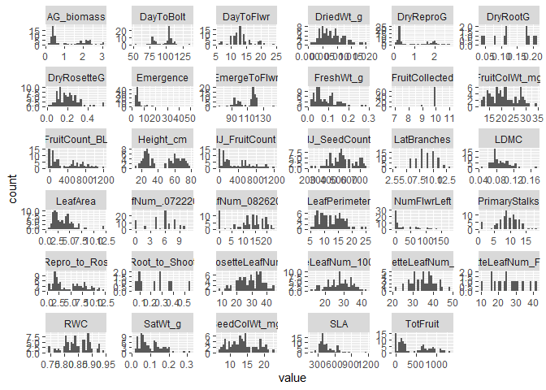

```r
# get a giant view of all the traits, not a super helpful figure honestly
CleanData_2021 %>% select_if(is.numeric) %>% gather(cols, value) %>%
  ggplot(aes(x = value)) +
  geom_histogram() +
  facet_wrap(.~cols, scales = "free")
```

Fresh weight of Single Leaf

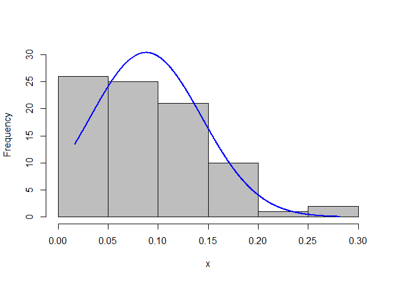

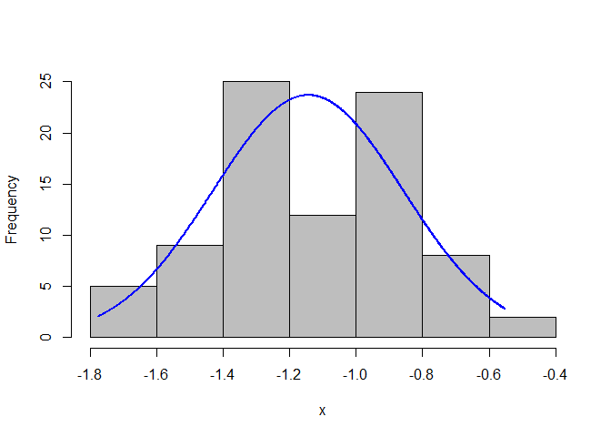

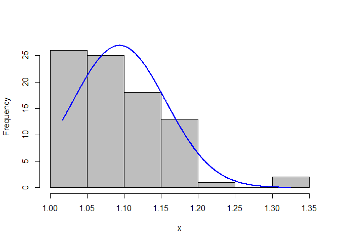

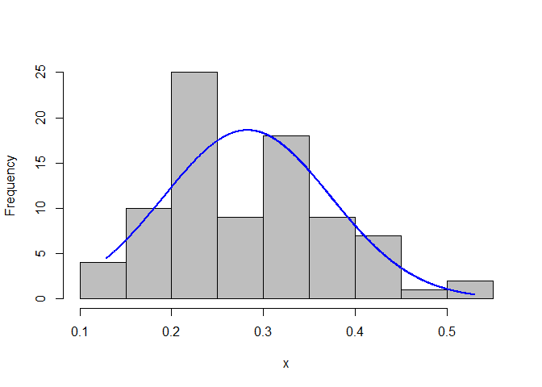

```
##
##  Shapiro-Wilk normality test
##
## data:  trait
## W = 0.9056, p-value = 1.233e-05
##
##
##  Shapiro-Wilk normality test
##
## data:  log10(trait)
## W = 0.97715, p-value = 0.1358
##
##
##  Shapiro-Wilk normality test
##
## data:  exp(trait)
## W = 0.88855, p-value = 2.293e-06
##
##
##  Shapiro-Wilk normality test
##
## data:  sqrt(trait)
## W = 0.96445, p-value = 0.01918
```

```r
explore_trans(CleanData_2021$FreshWt_g)
```

```r
# add column of log transformed information to dataframe
CleanData_2021$l10_FreshWt <- log10(CleanData_2021$FreshWt_g)
```

Saturated Weight of Single Leaf

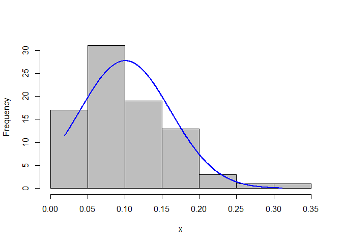

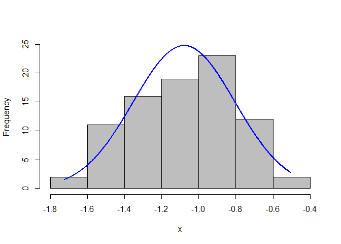

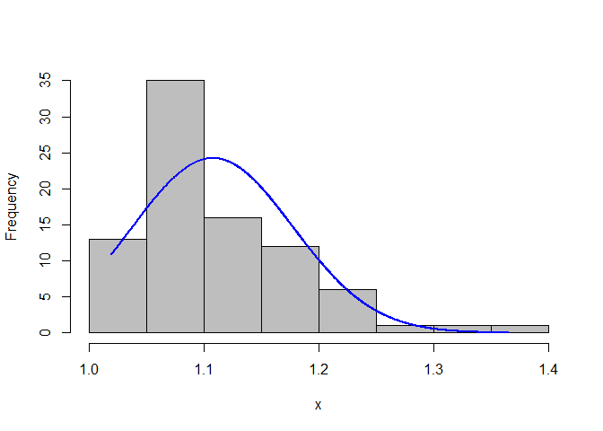

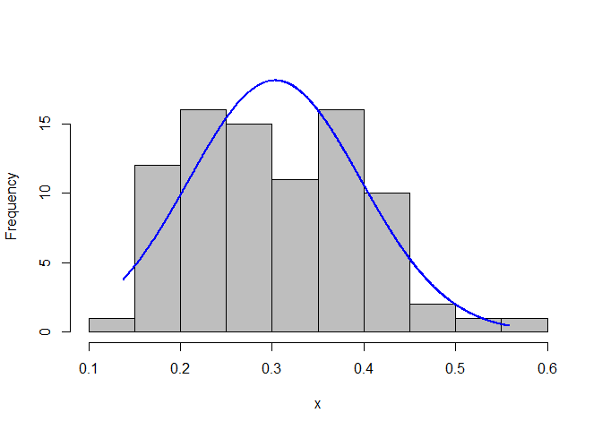

```
##
##  Shapiro-Wilk normality test
##
## data:  trait
## W = 0.91295, p-value = 2.675e-05
##
##
##  Shapiro-Wilk normality test
##
## data:  log10(trait)
## W = 0.97853, p-value = 0.1681
##
##
##  Shapiro-Wilk normality test
##
## data:  exp(trait)
## W = 0.89542, p-value = 4.434e-06
##
##
##  Shapiro-Wilk normality test
##
## data:  sqrt(trait)
## W = 0.96717, p-value = 0.02901
```

```r
explore_trans(CleanData_2021$SatWt_g)
```

```r
CleanData_2021$l10_SatWt <- log10(CleanData_2021$SatWt_g)
```

Dried Weight of Single Leaf

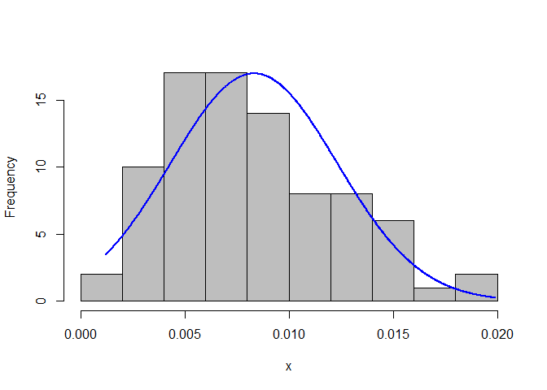

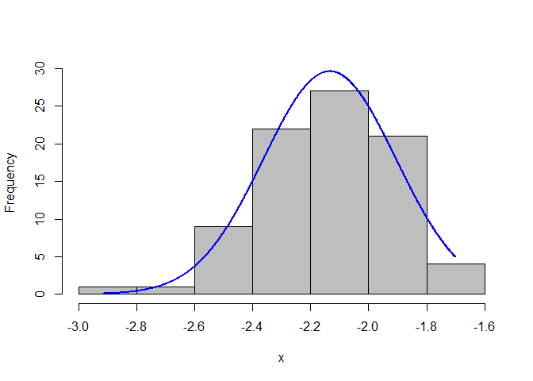

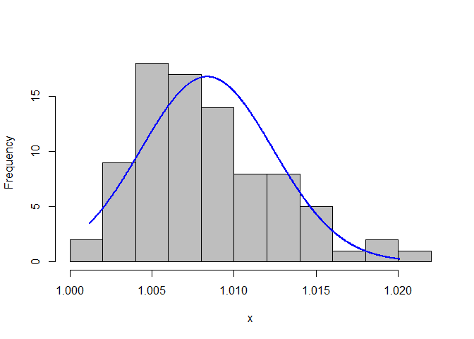

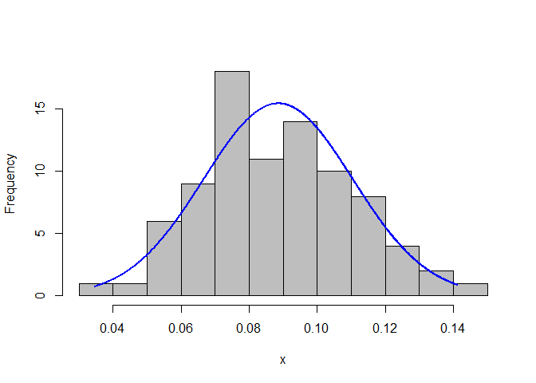

```
##
##  Shapiro-Wilk normality test
##
## data:  trait
## W = 0.95771, p-value = 0.007096
##
##
##  Shapiro-Wilk normality test
##
## data:  log10(trait)
## W = 0.97096, p-value = 0.05199
##
##
##  Shapiro-Wilk normality test
##
## data:  exp(trait)
## W = 0.95692, p-value = 0.006325
##
##
##  Shapiro-Wilk normality test
##
## data:  sqrt(trait)
## W = 0.99067, p-value = 0.808
```

```r
explore_trans(CleanData_2021$DriedWt_g)
```

```r
# sqrt is the best here, also do log for consistency
CleanData_2021$l10_DriedWt <- log10(CleanData_2021$DriedWt_g)
CleanData_2021$SQR_DriedWt <- sqrt(CleanData_2021$DriedWt_g)
```

Leaf Area of Single Leaf

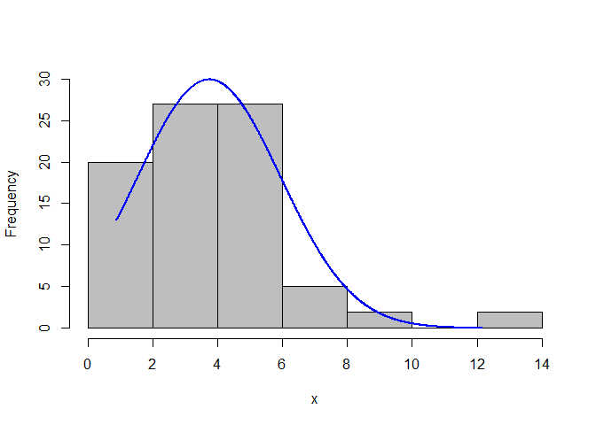

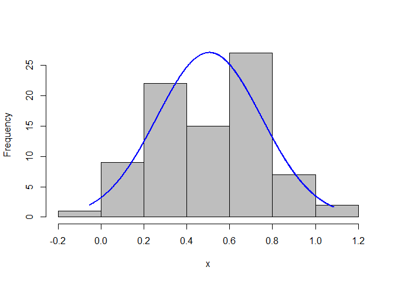

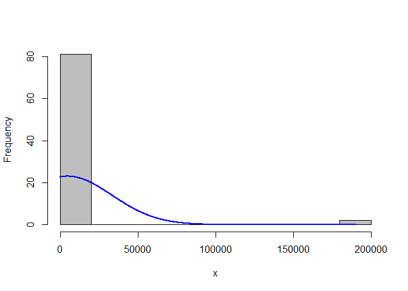

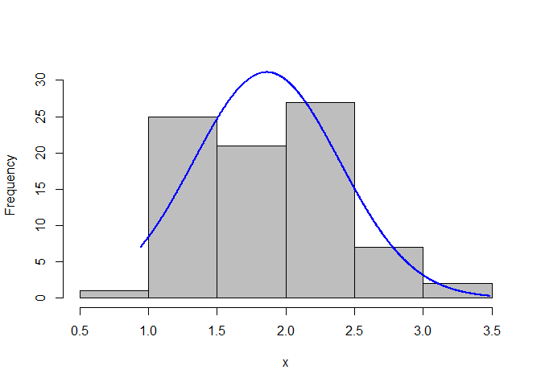

```
##
##  Shapiro-Wilk normality test
##
## data:  trait
## W = 0.87193, p-value = 6.526e-07
##
##
##  Shapiro-Wilk normality test
##
## data:  log10(trait)
## W = 0.98163, p-value = 0.2827
##
##
##  Shapiro-Wilk normality test
##
## data:  exp(trait)
## W = 0.14901, p-value < 2.2e-16
##
##
##  Shapiro-Wilk normality test
##
## data:  sqrt(trait)
## W = 0.95212, p-value = 0.003693
```

```r
explore_trans(CleanData_2021$LeafArea)
```

```r
# log ten is the best
CleanData_2021$l10_LeafArea <- log10(CleanData_2021$LeafArea)
```

Leaf Perimeter of Single Leaf

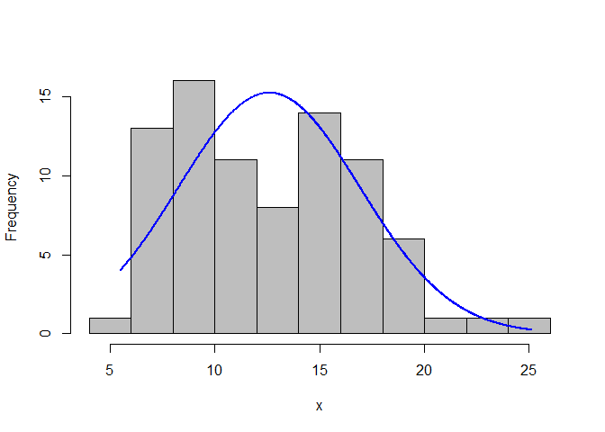

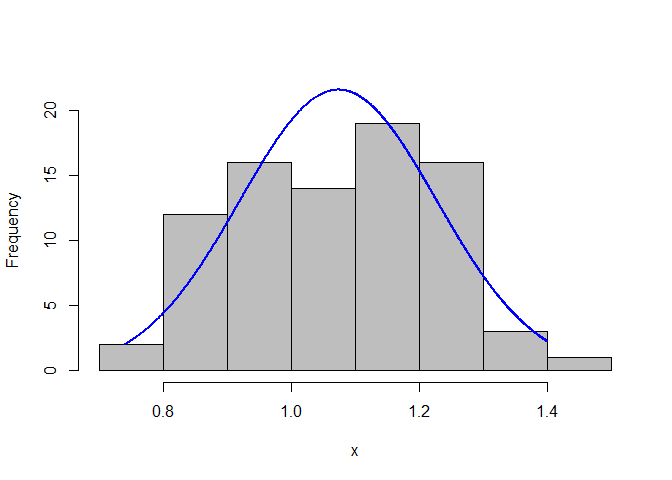

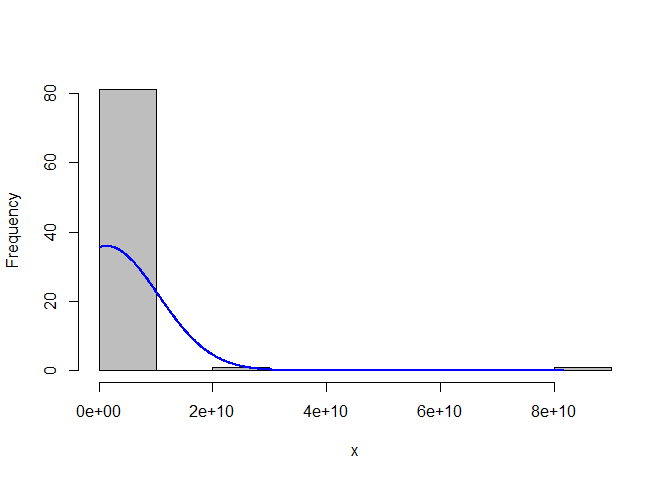

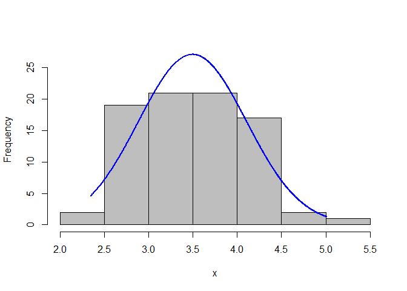

```
##
##  Shapiro-Wilk normality test
##
## data:  trait
## W = 0.95879, p-value = 0.009396
##
##
##  Shapiro-Wilk normality test
##
## data:  log10(trait)
## W = 0.97101, p-value = 0.05734
##
##
##  Shapiro-Wilk normality test
##
## data:  exp(trait)
## W = 0.12196, p-value < 2.2e-16
##
##
##  Shapiro-Wilk normality test
##
## data:  sqrt(trait)
## W = 0.9715, p-value = 0.06181
```

```r
explore_trans(CleanData_2021$LeafPerimeter)
```

```r
CleanData_2021$l10_LeafPer <- log10(CleanData_2021$LeafPerimeter)
```

Specific Leaf Area

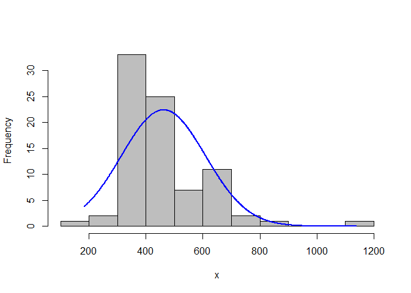

```r
#explore_trans(CleanData_2021$SLA)
#function throws an error so did it by hand (because of NAs, issue with exponential transformation)
plotNormalHistogram(CleanData_2021$SLA)
```

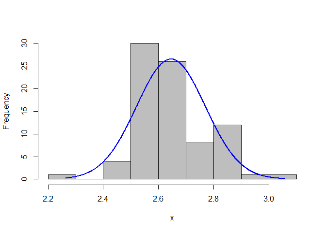

```r
  plotNormalHistogram(log10(CleanData_2021$SLA))
```

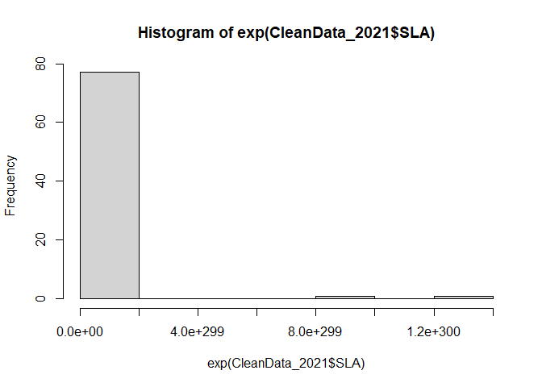

```r
  hist(exp(CleanData_2021$SLA))
```

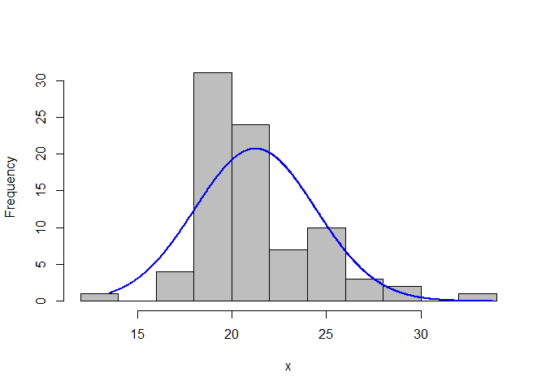

```r
  plotNormalHistogram(sqrt(CleanData_2021$SLA))
```

```r
  # want the one with the largest value
  print(shapiro.test(CleanData_2021$SLA))
```

```
##
##  Shapiro-Wilk normality test
##
## data:  CleanData_2021$SLA
## W = 0.85508, p-value = 1.607e-07
```

```r
  print(shapiro.test(log10(CleanData_2021$SLA)))
```

```
##
##  Shapiro-Wilk normality test
##
## data:  log10(CleanData_2021$SLA)
## W = 0.94791, p-value = 0.002092
```

```r
  print(shapiro.test(exp(CleanData_2021$SLA)))
```

```
##
##  Shapiro-Wilk normality test
##
## data:  exp(CleanData_2021$SLA)
## W = NaN, p-value = NA
```

```r
  print(shapiro.test(sqrt(CleanData_2021$SLA)))
```

```
##
##  Shapiro-Wilk normality test
##
## data:  sqrt(CleanData_2021$SLA)
## W = 0.91325, p-value = 3.39e-05
```